# What are related to people happy moments?

Yingqiao Zhang

September 15, 2018

```r
devtools::install_github("lchiffon/wordcloud2")
library(ggplot2)
library(dplyr)
library(wordcloud2)
library(tm)
library(topicmodels)
library(tidyverse)
library(tidytext)
library(DT)
library(scales)
library(wordcloud2)
library(gridExtra)
library(ngram)
```

```r
hm_data <- read.csv("processed_moments.csv")

urlfile<-'https://raw.githubusercontent.com/rit-public/HappyDB/master/happydb/data/demographic.csv'
demo_data <- read.csv(urlfile)
newdata <- hm_data %>% inner_join(demo_data,by='wid')
```

I will use two dataframes, hm_data which describes the happy moments and demo_data which records the personal information of people who shared their happy moments. Since these two dataframes could be joined together by wid column, I use inner_join function to get a new dataframe called ‘newdata’ which records all information in two elder dataframes.

First Part:Exploratory Data Analysis

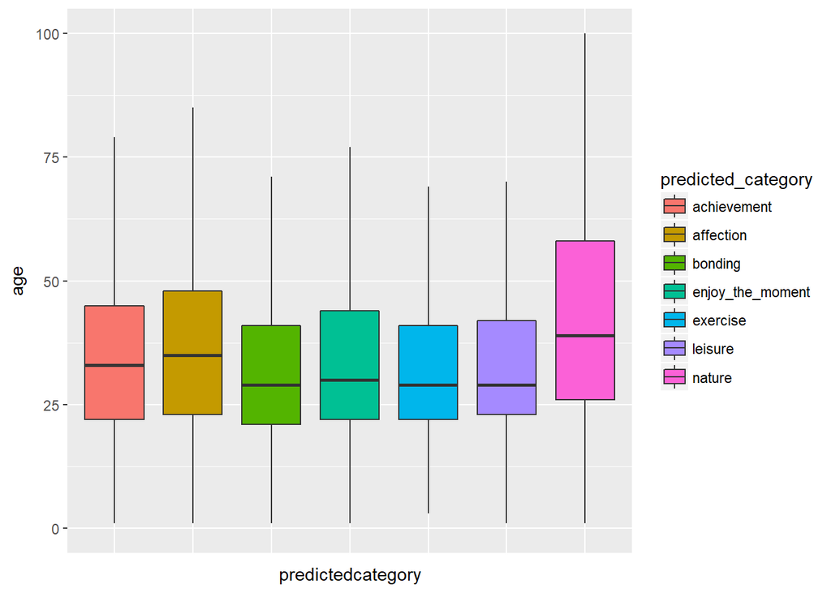

```r
newdata[,'age'] <- as.numeric(newdata[,'age'])
ggplot(data=newdata)+geom_boxplot(aes(x=predicted_category,y=age,fill=predicted_category),outlier.color=NA)+labs(x='predictedcategory',y='age')+theme(axis.text.x=element_blank(),axis.ticks.x=element_blank())+ylim(c(0,100))
```

```r
print(mean(newdata$age))
```

```
## [1] 37.24149
```

```r
for(i in c('m','f')){
  print(mean(filter(newdata,newdata$gender==i)[,'age']))
}
```

```
## [1] 34.5623
## [1] 41.01345
```

```r
for(i in c('single','married')){
  print(mean(filter(newdata,newdata$marital==i)[,'age']))
}
```

```
## [1] 28.94885
## [1] 45.1678
```

```r
for(i in c('n','y')){
  print(mean(filter(newdata,newdata$parenthood==i)[,'age']))
}
```

```
## [1] 30.36715
## [1] 47.87731
```

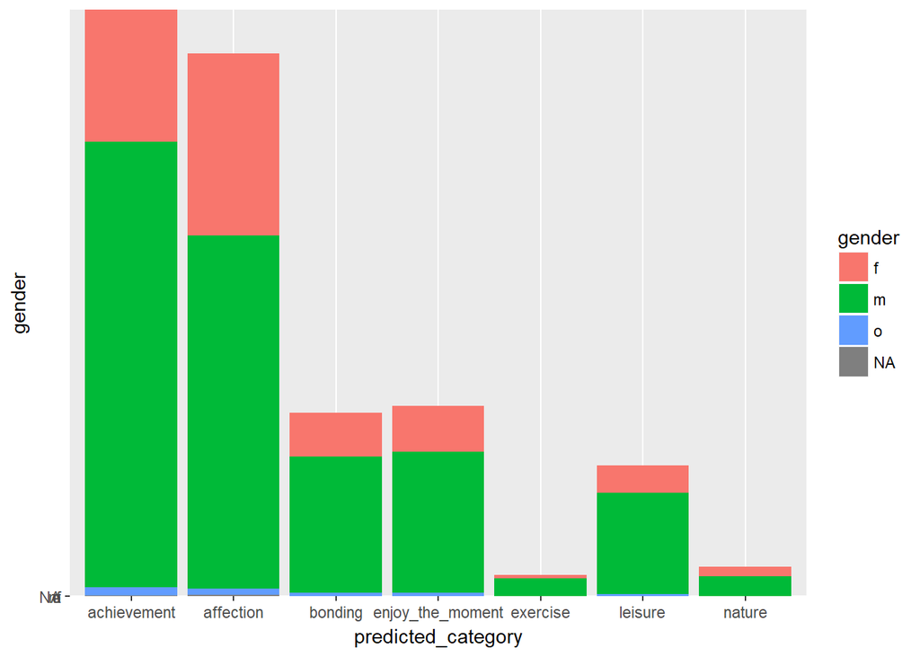

```r
newdata[,'gender'][newdata[,'gender']=='']<-NA
ggplot(data=newdata, aes(x=predicted_category, y=gender, fill=gender))    +  geom_bar(stat="identity")
```

From the graph above, we could see the distribution of these 7 different categories. From them, achievement and affection are the most two common happy moment categories and exercise is the most uncommon one. Classified by gender, I found that men shared achievement moments mostly, and women shared affection moments mostly. I think this is because men pay more attention to work and desired to be successful in career, and women pay more attention to family, to the relationship between others, and they would like to have a happy family and social circle.

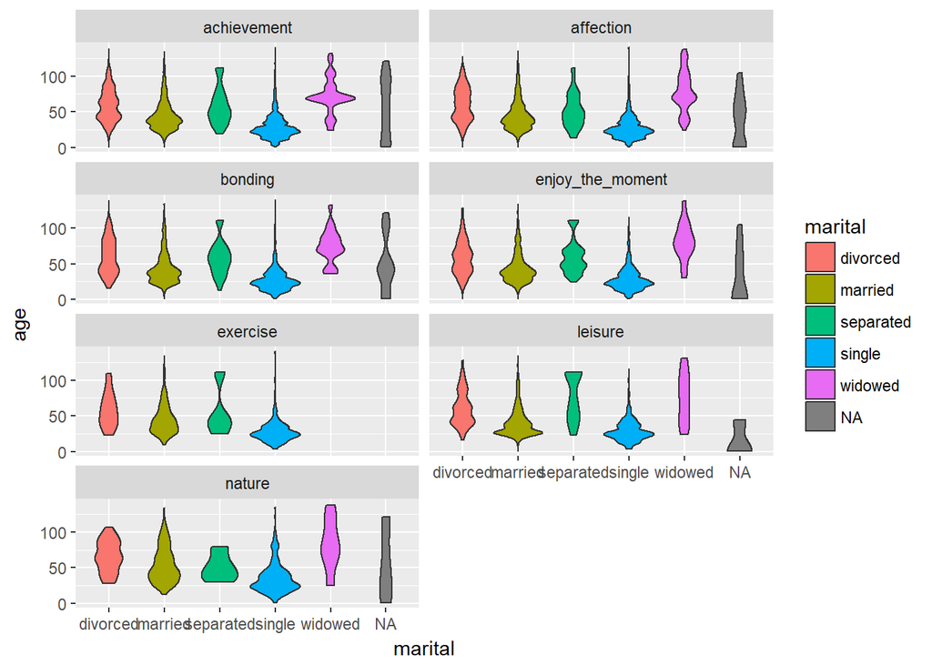

```r
newdata[,'marital'] <- factor(newdata[,'marital'],levels = c('divorced','married' ,'separated', 'single' ,'widowed'))
ggplot(newdata)+geom_violin(aes(marital,age,fill=marital))+facet_wrap(~predicted_category,nrow=4)
```

In the above graph, I used three variables, age, marital and category to visualize data. I found there is no widowed people who shared exercise moments.

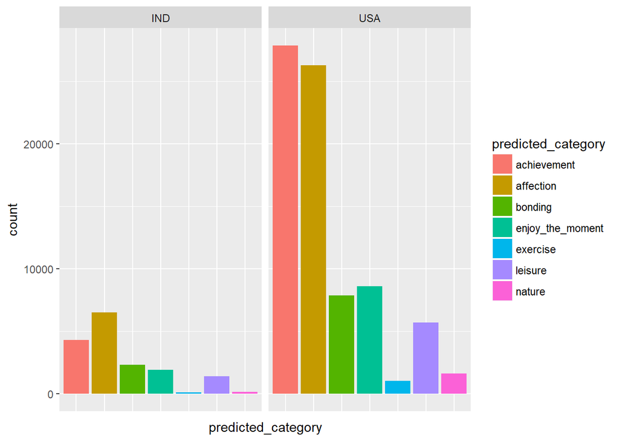

```r
countrydata <- newdata[newdata[,'country']=='USA'|newdata[,'country']=='IND',]
ggplot(countrydata)+geom_bar(aes(x=predicted_category,fill=predicted_category))+facet_wrap(~country)+theme(axis.text.x=element_blank(),axis.ticks.x=element_blank())
```

In the above graph, I choose USA and IND to make the comparison. The reason I choose them is these two countries occpies more than 90% population, so more samples, more approximate to real situation. Because of the data collecting area, I think the population difference between them doesn’t matter. I found that people in USA seem to pay more attention to achievement and people in IND pay more attention to affection. But in common, these two categories are their favourite two.

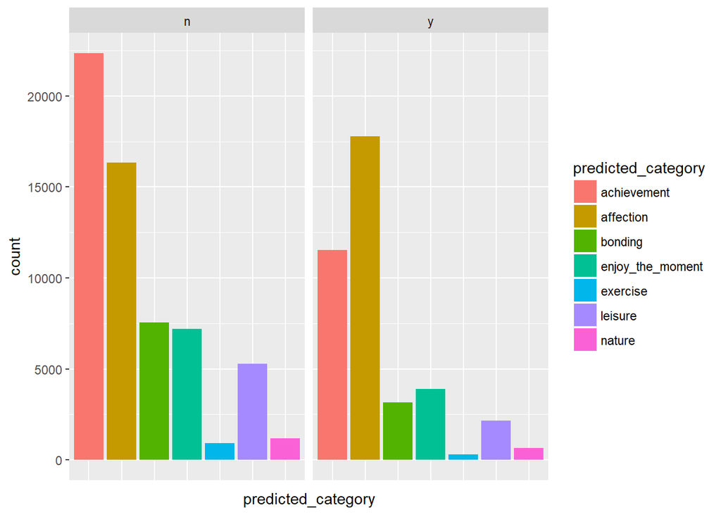

```r
parentdata <- newdata[newdata[,'parenthood']!='',]
ggplot(parentdata)+geom_bar(aes(x=predicted_category,fill=predicted_category))+facet_wrap(~parenthood)+theme(axis.text.x=element_blank(),axis.ticks.x=element_blank())
```

The graph above shows the difference in happy categories between parenthood and nonparenthood people. I found that people who are not a parent, they may get happiness from achievement easier, this is because they are young and hardworking in work or study, so this aspect interests them most. But after they become someone’s parent, they pay more attention to affection. Because in this time, they have family and children, love becomes their the most important thing gradually.

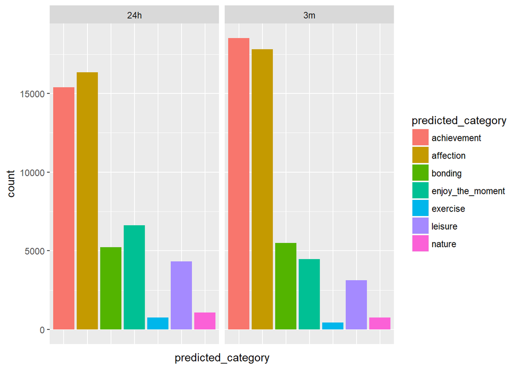

```r
ggplot(newdata)+geom_bar(aes(x=predicted_category,fill=predicted_category))+facet_wrap(~reflection_period)+theme(axis.text.x=element_blank(),axis.ticks.x=element_blank())
```

Second Part:Topic Modeling In this part I will use wordcloud to visualize the frequency of words from happy moments roughly. And also use bar chart to show the top 10 frequent words. At last, I will use LDA algorithm to cluster these happy moments and show the most frequent words in each topic.

```r
word<-c()
for(i in 1:nrow(newdata)){
  word<-c(word,strsplit(as.character(newdata[,'text'][i]),split=' '))
}
word<-unlist(word)
wordcloud2(sort(table(word),decreasing = T)[1:200],size=0.5,shape='star')
```

[interactive chart not shown]

I used text variable to make the wordcloud and choose the most frequent 200 words into the graph. From the graph I could know friend is the most frequent mentioned word, and people often feel happy when they are with their friends. Except friend, family and family members seem the second happiness source, family, husband, wife, mother, daughter,son, girlfriend, and so on. In place aspect, home and school are larger than others, seems these two places are good. In action aspect, watched, played are larger than others. It definitely is the truth. Everyone loves playing.

```r
mnewdata<-filter(newdata,newdata$gender=='m')
mword<-c()
for(i in 1:nrow(mnewdata)){
  mword<-c(mword,strsplit(as.character(mnewdata[,'text'][i]),split=' '))
}
mword<-unlist(mword)
wordcloud2(sort(table(mword),decreasing = T)[1:200],size=0.5,shape='star')
```

[interactive chart not shown]

```r
fnewdata<-filter(newdata,newdata$gender=='f')
fword<-c()
for(i in 1:nrow(fnewdata)){
  fword<-c(fword,strsplit(as.character(fnewdata[,'text'][i]),split=' '))
}
fword<-unlist(fword)
wordcloud2(sort(table(fword),decreasing = T)[1:200],size=0.5,shape='star')
```

[interactive chart not shown]

Two wordclouds above are separated by gender. The first one is male, second is female. From these two wordclouds, we could see that except friend,male often mentioned their wife,girlfriend, and game.Female often mentioned their husband, boyfriend, daughter.

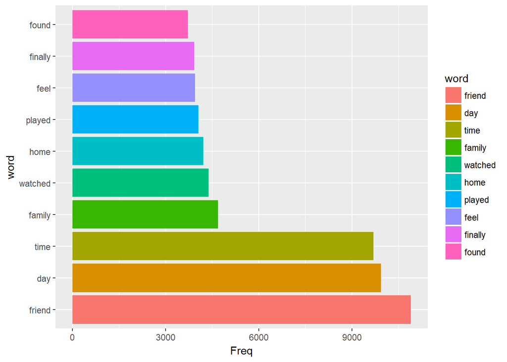

```r
fredata <- data.frame(sort(table(word),decreasing = T))
ggplot(data = fredata[1:10,])+geom_bar(aes(x=word,y=Freq,fill=word),stat = 'identity')+coord_flip()
```

Then I calculated the precise word frequency and showed them in bar chart. This time, I could believe that friend is the most important source of happiness.

```r
set.seed(12345)
randomrow<-sample(1:nrow(hm_data),10000)
lessdata <- hm_data$text[randomrow]
newfile<-as.list(as.character(lessdata))
newdocs<-VCorpus(VectorSource(newfile))
newdocs <-tm_map(newdocs,content_transformer(tolower))
transpose <- content_transformer(function(x, pattern) { return (gsub(pattern,' ', x))})
newdocs <- tm_map(newdocs, transpose, ',')
writeLines(as.character(newdocs[[1]]))
```

```
## attended friend school annual day function
```

```r
newdtm<-DocumentTermMatrix(newdocs)
newfreq <- colSums(as.matrix(newdtm))
neword <- order(newfreq,decreasing=TRUE)
head(newfreq[neword],10)
```

```
##  friend     day    time watched  family    feel   found finally    home
##    1062    1004     902     469     465     427     401     399     385
## enjoyed
##     367
```

```r
burnin <- 4000
iter <- 1000
thin <- 500
seed <-list(2003,5,63,100001,765)
nstart <- 5
best <- TRUE
k <- 7
newldaOut <-LDA(newdtm,k, method='Gibbs', control=list(nstart=nstart, seed = seed,best=best, burnin = burnin, iter = iter, thin=thin))
newldaOut.topics <- as.matrix(topics(newldaOut))
head(newldaOut.topics,10)
```

```
##    [,1]
## 1     2
## 2     3
## 3     6
## 4     2
## 5     7
## 6     2
## 7     5
## 8     7
## 9     3
## 10    2
```

```r
newldaOut.terms <- as.matrix(terms(newldaOut,5))
newldaOut.terms
```

```
##      Topic 1     Topic 2    Topic 3  Topic 4   Topic 5  Topic 6
## [1,] "morning"   "finally"  "friend" "watched" "time"   "found"
## [2,] "dog"       "daughter" "played" "enjoyed" "family" "bought"
## [3,] "hours"     "job"      "game"   "night"   "feel"   "car"
## [4,] "walk"      "received" "visit"  "dinner"  "life"   "money"
## [5,] "beautiful" "school"   "talked" "husband" "moment" "free"
##      Topic 7
## [1,] "day"
## [2,] "home"
## [3,] "son"
## [4,] "birthday"
## [5,] "house"
```

```r
topicProbabilities <- as.data.frame(newldaOut@gamma)
topicProbabilities[1:10,]
```

```
##           V1        V2        V3        V4        V5        V6        V7
## 1  0.1275510 0.1632653 0.1632653 0.1275510 0.1275510 0.1275510 0.1632653
## 2  0.1210654 0.1380145 0.1549637 0.1380145 0.1549637 0.1549637 0.1380145
## 3  0.1098901 0.1098901 0.1868132 0.1252747 0.1252747 0.2021978 0.1406593
## 4  0.1347709 0.1536388 0.1536388 0.1347709 0.1347709 0.1347709 0.1536388
## 5  0.1428571 0.1253133 0.1253133 0.1604010 0.1253133 0.1253133 0.1954887
## 6  0.1347709 0.1536388 0.1536388 0.1536388 0.1347709 0.1347709 0.1347709
## 7  0.1298701 0.1298701 0.1298701 0.1298701 0.1844156 0.1298701 0.1662338
## 8  0.1006036 0.1991952 0.1146881 0.1146881 0.1287726 0.1287726 0.2132797
## 9  0.1373626 0.1373626 0.1565934 0.1373626 0.1565934 0.1373626 0.1373626
## 10 0.1298701 0.1844156 0.1480519 0.1298701 0.1298701 0.1480519 0.1298701
```

```r
topic1ToTopic2 <- lapply(1:nrow(newdtm),function(x)sort(topicProbabilities[x,])[k]/sort(topicProbabilities[x,])[k-1])
topic1ToTopic2[1:10]
```

```
## [[1]]
##   V7
## 1  1
##
## [[2]]
##   V6
## 2  1
##
## [[3]]
##         V6
## 3 1.082353
##
## [[4]]
##   V7
## 4  1
##
## [[5]]
##        V7
## 5 1.21875
##
## [[6]]
##   V4
## 6  1
##
## [[7]]
##         V5
## 7 1.109375
##
## [[8]]
##         V7
## 8 1.070707
##
## [[9]]
##   V5
## 9  1
##
## [[10]]
##          V2
## 10 1.245614
```

```r
topic2ToTopic3 <- lapply(1:nrow(newdtm),function(x)sort(topicProbabilities[x,])[k-1]/sort(topicProbabilities[x,])[k-2])
topic2ToTopic3[1:10]
```

```
## [[1]]
##   V3
## 1  1
##
## [[2]]
##   V5
## 2  1
##
## [[3]]
##         V3
## 3 1.328125
##
## [[4]]
##   V3
## 4  1
##
## [[5]]
##         V4
## 5 1.122807
##
## [[6]]
##   V3
## 6  1
##
## [[7]]
##     V7
## 7 1.28
##
## [[8]]
##         V2
## 8 1.546875
##
## [[9]]
##     V3
## 9 1.14
##
## [[10]]
##    V6
## 10  1
```

In this part, I used tm and topicmodels packages to achieve LDA algorithm. Since this dataset is too large to be analyzed, I randomly choose 10000 samples from population. Before analysis, I preprocessed data, transposed all letters to lower and strip all comma which may badly affect the result.Then I set parameters of LDA algorithm, since there are 7 different categories, I also set 7 topic. Finally, I got the topic of each happy moments by LDA algorithm.Also, I got 5 most frequent words in each topic. But it’s not enough. Because these topic assignment may have mistakes, a happy moment could be wrongly assigned easily. So I also calculated the probability of happy moments assigned to each topic. At last, I calculated the relative importance of certain happy moment’s second assignment and third assignment, this is another way to see whether a happy moment should be assigned into more than one topic.